# Week 1 report

In this notebook I am computing the functions that are mentioned in the *Week 1 Report*. When possible, I compare my results with those obtained via the ‘compositions’ package.

```r
library(compositions)
```

## 1.1. First Definitions

### Function 1. Which of these variables are compositional?

This function takes a set of variables in a list (each of them matrices or vectors) and returns a vector of zeros and ones. The component in position *i*, associated to the *i* position of the input vector, should be one if that matrix add up to a constant value and zero otherwise. This could be adjusted to add up approximately to a constant because of the roundings in transformed variables and so.

```r
which_coda=function(l,eps){ # l = list of variables, # eps = allowed error
  result = numeric()
  for (i in l){
    if (is.integer(dim(i)[2])==TRUE){
      range = max(rowSums(i))-min(rowSums(i))
      if (range<=eps){result <- c(result, 1)}
      else{result <- c(result, 0)}
    }
    else{result <- c(result, 0)}
  }
  return(result)
}
```

We are doing a tiny example for a simple vector which cannot be compositional data by definition, a matrix which apparently is a compositional vector and a matrix that is not.

```r
m1 = matrix(c(0.25,0.249999,0.2,0.2))
m1 <- cbind(m1, c(0.3, 0.3, 0.3, 0.35))
m1 <- cbind(m1, c(0.45, 0.45, 0.5, 0.45)) # definig the comp matrix

m2 = matrix(c(0.25,0.249999,0.2,0.2))
m2 <- cbind(m2, c(0.3, 0.9, 0.3, 0.35))
m2 <- cbind(m2, c(0.45, 0.45, 0.5, 0.65)) # definig the non comp matrix

v1 = c(1,2,2,1) # simple vector
lex = list(v1,m1,m2)
```

Vector:

```r
v1
```

```
[1] 1 2 2 1
```

Compositional Matrix:

```r
m1
```

```
         [,1] [,2] [,3]
[1,] 0.250000 0.30 0.45
[2,] 0.249999 0.30 0.45
[3,] 0.200000 0.30 0.50
[4,] 0.200000 0.35 0.45
```

Non Compositional Matrix:

```r
m2
```

```
         [,1] [,2] [,3]
[1,] 0.250000 0.30 0.45
[2,] 0.249999 0.90 0.45
[3,] 0.200000 0.30 0.50
[4,] 0.200000 0.35 0.65
```

Results if no deviation for the sum of the components is allowed:

```r
which_coda(lex,0)
```

```
[1] 0 0 0
```

Results if a tiny (0.001) deviation for the sum of the components is allowed:

```r
which_coda(lex,0.001)
```

```
[1] 0 1 0
```

### Function 2. Closed form operator.

This function returns the closed form of a given compositional vector (given as a matrix).

```r
C=function(x, k){ # x the matrix of the variable, k the constant (=1 if missing)
  if (missing(k)){
    newx <- (x)/rowSums(x)
    return(newx)
  }
  else{
    newx <- (k*x)/rowSums(x)
    return(newx)
  }
}
```

An example with the previously defined “m2” FOR $k=1$:

```r
C(m2)
```

```
          [,1]      [,2]      [,3]
[1,] 0.2500000 0.3000000 0.4500000
[2,] 0.1562495 0.5625004 0.2812502
[3,] 0.2000000 0.3000000 0.5000000
[4,] 0.1666667 0.2916667 0.5416667
```

An example with the previously defined “m2” FOR $k=100$:

```r
C(m2,100)
```

```
         [,1]     [,2]     [,3]
[1,] 25.00000 30.00000 45.00000
[2,] 15.62495 56.25004 28.12502
[3,] 20.00000 30.00000 50.00000
[4,] 16.66667 29.16667 54.16667
```

### Function 3. Naive Ternary plot (from scratch).

Here is the code for plotting ternary diagrams. Its input is a matrix with the compositional data and its output the aforementioned plot. Of course, it is very naive -yet-.

```r
ternary=function(mat){ # depends only in the data matrix containing the compositional datA
  x = mat[1,][1]
  y = mat[1,][2]
  z = mat[1,][3]
  p=c(0.5*(2*y+z)/(x+y+z), sqrt(3/2)*(z/(x+y+z)))
  plot(p[1],p[2],xlim=c(0,1),ylim=c(0,1), pch=20,xlab=" ",ylab=" ", cex=0.5)
  if (nrow(mat)>1){
    for (i in 2:nrow(mat)){
    x = mat[i,][1]
    y = mat[i,][2]
    z = mat[i,][3]
    p=c(0.5*(2*y+z)/(x+y+z), sqrt(3/2)*(z/(x+y+z)))
    points(p[1],p[2],pch=20, cex=0.5)
    }
  }
  segments(0,0,1,0)
  segments(0.5,sqrt(3/4),0,0)
  segments(0.5,sqrt(3/4),1,0)
}
```

And here, one example with out 4 row “m2” matrix:

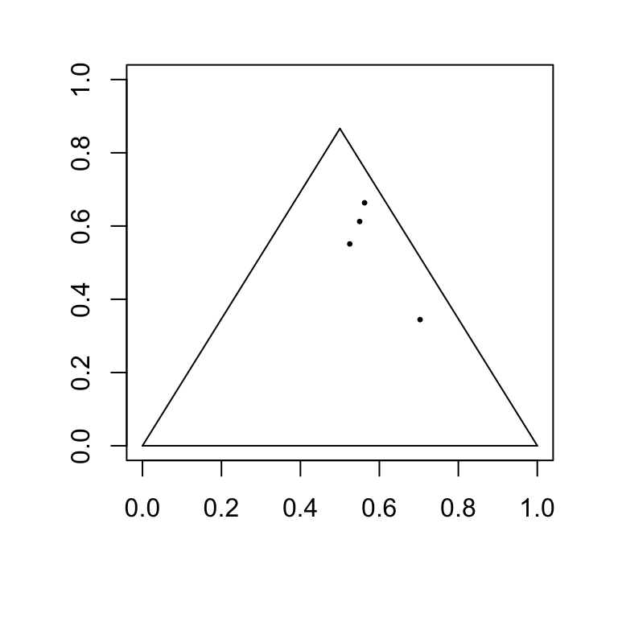

```r
ternary(m2)
```

I will test the ‘compositions’ ternary diagram:

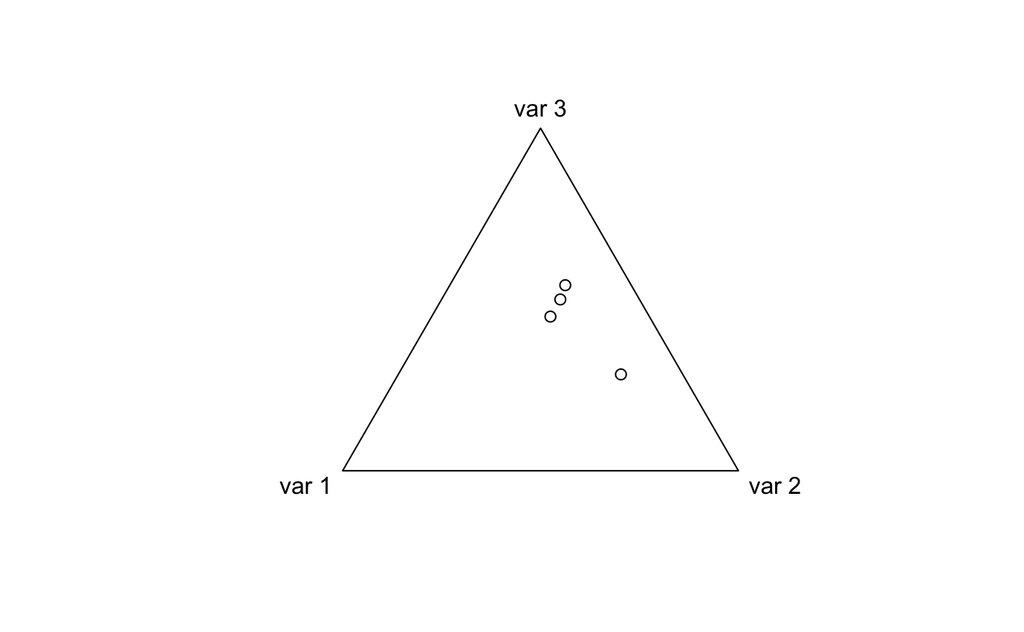

```r
ac=acomp(m2)
plot(ac)
```

*Surprisingly, it doesn’t make that much difference…*

## 1.2.1 The Aitchison Geometry (Operations)

### Function 4. The perturbation.

The perturbation in the Aitchison geometry is defined as $\mathbf{x}\oplus\mathbf{p} = \mathcal{C}[x_1p_1,...,x_Dp_D]$:

```r
pt = function (x,y){ # I prefer to keep an easy name for this kind of functions, x and y are matrix 1xD
  return(C(x*y))
}
```

We define $x_1$ and $x_2$ and use the perturbation operation.

```r
x1 = t(matrix(c(0.3,2,1,3)))
x2 = t(matrix(c(3,  1,2,4)))

pt(x1,x2)
```

```
           [,1]      [,2]      [,3]      [,4]
[1,] 0.05325444 0.1183432 0.1183432 0.7100592
```

We can see that $x_1 \oplus x_2$ lies in the simplex.

```r
sum(pt(x1,x2)) # arreglar PT
```

```
[1] 1
```

Here I replicate the example given in the “Transformations” document:

```r
pt(t(matrix(c(1,2,3))),t(matrix(c(1,2,1))))
```

```
      [,1] [,2]  [,3]
[1,] 0.125  0.5 0.375
```

### Function 5. The powering.

The powering function is defined by $\lambda \odot \mathbf{x} = \mathcal{C}[x_1^\lambda,...,x_D^\lambda]$.

```r
pw=function(l,x){ # x the vector (matrix 1xD) and l stands for the scalar
  return(C(x**l))
}
```

As an example, $2\odot x_1$, which should coincide with $x_1\oplus x_1$:

```r
pw(2,x1) # powering
```

```
            [,1]      [,2]       [,3]      [,4]
[1,] 0.006387509 0.2838893 0.07097232 0.6387509
```

```r
pt(x1,x1) # perturbation
```

```
            [,1]      [,2]       [,3]      [,4]
[1,] 0.006387509 0.2838893 0.07097232 0.6387509
```

… and the “transformations” document example:

```r
pw(2,t(matrix(c(1,2,1)))) # perturbationx
```

```
          [,1]      [,2]      [,3]
[1,] 0.1666667 0.6666667 0.1666667
```

### Function 6. The Aitchison inner product.

The inner product of this geometry is defined as: $\langle \mathbf{x}, \mathbf{y} \rangle_A = \dfrac{1}{D} \sum_{i=1}^{D-1}\sum_{j=i+1}^{D} \ln\dfrac{x_i}{x_j}\ln\dfrac{y_i}{y_j}$.

```r
inner = function(x,y){ # x, y are Dx1 matrices
  result = 0
  D = ncol(x)
  for (i in (1:(D-1))){
    result <- result + sum(log(x[i]/x[(i+1):D])*(log(y[i]/y[(i+1):D])))
  }
  return((1/D)*result)
}
```

```r
inner(x1,x2)
```

```
[1] -0.2667037
```

### Function 7. The Aitchison distance.

The distance is defined as $d_A(\mathbf{x},\mathbf{y}) = \left(\dfrac{1}{D} \sum_{i=1}^{D-1}\sum_{j=i+1}^{D} \left(\ln\dfrac{x_i}{x_j}-\ln\dfrac{y_i}{y_j}\right)^2\right)^{1/2}$

```r
dist = function(x,y){ # x,y 1xD matrices
  result = 0
  D = ncol(x)
  for (i in (1:(D-1))){
    result <- result + sum((log(x[i]/x[(i+1):D])-(log(y[i]/y[(i+1):D])))**2)
  }
  return(((1/D)*result)**(1/2))
}
```

As any distance, $d_A(x_1,x_1)$ should be equal to 0 and positive otherwise:

```r
dist(x1,x1)
```

```
[1] 0
```

```r
dist(x1,x2)
```

```
[1] 2.1606
```

I cannot get the equality between norm(x-y) and distance(x,y), despite it is stated in the page (p.41) of the transformations document (maybe **only a feature of the ‘compositions’ package**? Yes! That is!). Empirically, I even get an error because $z:=x-y$ has positive and negative components and, therefore, $ln(z_i/z_j)$ should be calculated and $\exists\; i,j$ such that $z_i\cdot z_j<0$

```r
dist(x1,x2)
```

```
[1] 2.1606
```

```r
sqrt(inner(x1-x2,x1-x2))
```

```
NaNs producedNaNs producedNaNs producedNaNs produced
```

```
[1] NaN
```

```r
x1c = acomp(x1)
x2c = acomp(x2)
norm(x1c-x2c) # composition package norm
```

```
[1] 2.1606
```

### Function 8. Linear operator.

The linear operator is defined as $A\boxdot\mathbf{x} = \mathcal{C}\left(\prod_{j=1}^D x_j^{a_{1j}},...,\prod_{j=1}^D x_j^{a_{Dj}}\right)^T$ for $A$ a DxD matrix and $x$ a 1xD vector.

```r
lin = function (A, x){ # A matrix, x vector 1xD
  vec=numeric()
  for (i in 1:nrow(A)){
    vec=c(vec,prod(x[i]**A[i,]))
  }
  return(C(t(vec)))
}
```

Here the function is tested:

```r
  v3=matrix(c(0.4,0.2,0.4)) # defining a vector
  m3 = matrix(c(0.4,0.4,0.3))
  m3 <- cbind(m3, c(0.3,0.1,0.3)) # defining a square matrix
  m3 <- cbind(m3, c(0.2,0.5,0.4))
  lin(m3,v3)
```

```
          [,1]      [,2]      [,3]
[1,] 0.4221787 0.1926071 0.3852142
```

## 1.2.2 The Aitchison Geometry (Transformations)

### Function 9. The alr transfomration.

The alr transformation is given by: $\mathrm{alr}(\mathbf{x})=(\ln(x_1/x_D),...,\ln(x_{D-1}/x_D))$

```r
alr = function(x,i){   # x is a 1xD matrix, i an integer in (1,D): the "reference" element
  if (missing(i)){     # if i is not given, the last element is used
    return(log(x/x[length(x)])[-length(x)])
  }
  else{
    return(log(x/x[i])[-i])
  }
}
```

For example, the transformation for $x_1$:

```r
alr(x1)
```

```
[1] -2.3025851 -0.4054651 -1.0986123
```

And it coincides with the result of the ‘compositions’ package:

```r
compositions::alr(x1)[1,]
```

```
[1] -2.3025851 -0.4054651 -1.0986123
```

### Function 10. The ilr transformation.

The ilr transformation is given by:

$\mathrm{ilr}(\mathbf{x})=\mathbf{V}^T_D\ln(\mathbf{x}):=x^*$

For the 3-component case (the function should be extended if needed), the matrix $\mathbf{V}_3$ is given by: $\mathbf{V}_3 = \left( \begin{matrix} \sqrt\frac{2}{3} & 0 \\ -\frac{1}{\sqrt6} & \frac{1}{\sqrt2} \\ -\frac{1}{\sqrt6} & -\frac{1}{\sqrt2}\end{matrix}\right)$

```r
ilr = function(x){ # x matrix 1xD as always (deprecated)
  V3 = matrix(c(sqrt(2/3),-sqrt(1/6),-sqrt(1/6)))
  V3 <- cbind(V3, c(0,sqrt(1/2),-sqrt(1/2))) # defining V3
  return(t(V3)%*%log(x))
}
```

```r
x3=c(0.4,0.2,0.4)
ilr(x3)
```

```
           [,1]
[1,]  0.2829762
[2,] -0.4901291
```

### Function 11. The ilr inverse.

For this, the exponential of a matrix is needed. I will compute a naive Taylor-series based one (in order to avoid using external packages for the moment):

```r
expm = function(M, iter){ # matrix and number of iterations (the more the better)
  if (missing(iter)){     # if i is not given, the last element is used
    iter=100
  }
  res=diag(length(M[1,]))
  power=M
  for (i in 1:iter){
    res = res + power/factorial(i)
    power = power%*%M
  }
  return(res)
}
```

It works quite well!

```r
test1 <- t(matrix(c(4, 2, 0,1, 4, 1,1, 1, 4), 3, 3))
expm(test1,100)
```

```
         [,1]     [,2]      [,3]
[1,] 147.8666 183.7651  71.79703
[2,] 127.7811 183.7651  91.88257
[3,] 127.7811 163.6796 111.96811
```

Of course, this was not needed. I did not realise the dimensions.

Now, the inverse ilr (only for the D=3 case): $x=\mathrm{ilr}^{-1}(\mathbf{x}^*) = \mathcal{C}(\exp(\mathbf{V}_D x^*)$

```r
inverseilr=function(x){ # x is x*, vec of coordinates
  V3 = matrix(c(sqrt(2/3),-sqrt(1/6),-sqrt(1/6)))
  V3 <- cbind(V3, c(0,sqrt(1/2),-sqrt(1/2))) # defining V3
  return(C(t((exp(V3%*%x)))))
}
```

Testing the new function for $x_3$, we should have $\mathrm{ilr}^{-1}(\mathrm{ilr(\mathbf{x})})=\mathbf{x}$. Perfect! *(there was a bug in previous versions, I forgot a “log” somewhere)*

```r
x3
```

```
[1] 0.4 0.2 0.4
```

```r
inverseilr(ilr(x3))
```

```
     [,1] [,2] [,3]
[1,]  0.4  0.2  0.4
```

Now that I have read in the transformations document the explicit formula of $\mathbf{V}$ I can make a function to compute it here:

```r
V_D = function(D){ # D is the dimension (parts)
  V_D = matrix(0L, nrow =D , ncol = D-1)
  for (i in 1:(D-1)){  # pseudodiagonal elements
    V_D[i,i] = (D-i)/(sqrt((D-i+1)*(D-i)))
  }
  for (i in 2:D){ # below pseudodiagonal elements
    for (j in 1:i-1){
      V_D[i,j]=-1/(sqrt((D-j+1)*(D-j)))
    }
  }
  return(V_D)
}
```

The matrix $V_3$ had been computed previously. It is checked that they coincide:

```r
V3 = matrix(c(sqrt(2/3),-sqrt(1/6),-sqrt(1/6)))
V3 <- cbind(V3, c(0,sqrt(1/2),-sqrt(1/2))) # defining V3 as before
V3
```

```
           [,1]       [,2]
[1,]  0.8164966  0.0000000
[2,] -0.4082483  0.7071068
[3,] -0.4082483 -0.7071068
```

```r
V_D(3) # our brand new function
```

```
           [,1]       [,2]
[1,]  0.8164966  0.0000000
[2,] -0.4082483  0.7071068
[3,] -0.4082483 -0.7071068
```

Now, it is possible to update the ilr function:

```r
ilr = function(x){ # x matrix N x D
  x = C(x)
  V = V_D(dim(x)[2])
  return(t(t(V)%*%t(log(x))))
}
```

```r
testvec = t(matrix(c(1,2,4)))
ilr(testvec)
```

```
           [,1]       [,2]
[1,] -0.8489285 -0.4901291
```

However… (I can assume the first and the second coordinates are interchangables, and also that (x,y), (-x, -y) are equivalent representations, but…). I have found that the ‘compositions’ package what does here is $\mathrm{ilr}(x) = V^T \mathrm{clr}(x)$.

```r
ac = acomp(c(1,2,4))

compositions::ilr(ac)
```

```
          [,1]      [,2]
[1,] 0.4901291 0.8489285
attr(,"class")
[1] "rmult"
```

## 1.3. Regressions

The good news is that the ilr transformation defined previously works with (the transpose of) matrices; the bad is that the regression cannot be done yet (remark that both the independent and dependent variables could be matrices).

```r
ilr(t(m2))
```

```
           [,1]       [,2]       [,3]
[1,]  0.1288331  0.1821927  0.0000000
[2,] -0.3616415  0.8340814 -0.1090010
[3,] -0.1365680 -0.1931363 -0.1855196
```

## 1.4. Descriptive Analysis of Compositional Data

### Function 12. The compositional mean.

The compositional mean of a variable $\mathbf{x}$ is given by:

$\bar{\mathbf{x}} = \dfrac{1}{N} \odot \bigoplus^N_{n=1}\mathbf{x}_n = \mathcal{C}\left(\exp\left(\dfrac{1}{N}\sum_{n=1}^N \ln(\mathbf{x}_n) \right)\right)$

```r
c_mean=function(x){ #x is a matrix NxD
  mult = t(matrix(x[1,]))
  for (i in (2:(dim(x)[1]))){
    mult=pt(mult,t(matrix(x[i,])))
  }
  res = pw(1/dim(x)[1], mult)
  return(res)
}
```

For example:

```r
c_mean(m1)
```

```
          [,1]      [,2]     [,3]
[1,] 0.2241885 0.3125984 0.463213
```

And it coincides with the ‘compositions’ package mean:

```r
mean(acomp(m1))
```

```
[1] 0.2241885 0.3125984 0.4632130
attr(,"class")
[1] acomp
```

We can visualise it. It should be the center of the other points. *In this ternary diagramm, the mean is represented by point that is surrounded by the other three. It does not look good.*

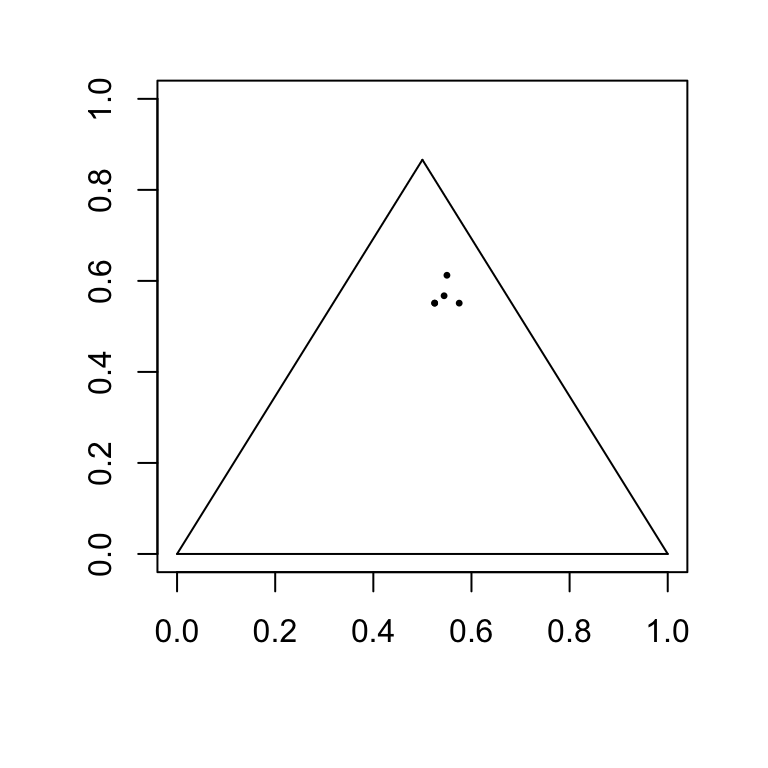

```r
ternary(rbind(m1,c_mean(m1)))
```

### Function 13. The total variance.

The total variance for a compositional variable $\mathbf{x}$ is defined as:

$\mathrm{tvar}(\mathbf{x})=\dfrac{1}{N-1}\sum_{n=1}^N d_A^2(\mathbf{x}_n, \bar{\mathbf{x}})$

```r
tvar = function(x){ # x is a NxD matrix
  m = c_mean(x)
  suma=0
  N = dim(x)[1]
  for (i in 1:N){
    suma = suma + (dist(t(matrix(x[i,])),m))**2
  }
  return(suma/(N-1))
}
```

It coincides with the ‘compositional’ package result for $m_1$:

```r
tvar(m1)
```

```
[1] 0.02421196
```

```r
mvar(acomp(m1))
```

```
[1] 0.02421196
```

### Function 14. The Standard Deviation.

The SD for compositional data can be defined through the total variance as:

$\mathrm{tsd}(\mathbf{x})=\sqrt{\dfrac{1}{D-1}\mathrm{tvar}(\mathbf{x})}$

```r
csd = function(x){ # x NxD matrix
  D = dim(x)[2]
  return(sqrt(tvar(x)/(D-1)))
}
```

E.g.:

```r
csd(m1)
```

```
[1] 0.1100272
```

### Function 15. Variation Matrix.

The Variation Matrix is defined empirically as a DxD matrix with components:

$\hat{\tau}_{ij} = \dfrac{1}{N-1}\sum_{n=1}^N \ln^2 \dfrac{x_{ni}}{x_{nj}} - \ln^2 \dfrac{\bar{x_i}}{\bar{x_j}}$

```r
varm = function(x){ # x is a NxD matrix
  N=dim(x)[1]
  D=dim(x)[2]
  m = c_mean(x)
  res = matrix(0,D,D)
  for (i in 1:D){
    for (j in 1:D){
      res[i,j]=(1/(N-1))*(sum((log(x[,i]/x[,j]))**2))-(log(m[1,i]/m[1,j]))**2
    }
  }
  return(res)
}
```

If we compute it for $m_1$, it should coincide with the ‘compositions’ package variation:

```r
varm(m1)
```

```
           [,1]       [,2]       [,3]
[1,] 0.00000000 0.07084081 0.20275598
[2,] 0.07084081 0.00000000 0.06297584
[3,] 0.20275598 0.06297584 0.00000000
```

```r
compositions::variation(acomp(m1))
```

```
           [,1]       [,2]       [,3]
[1,] 0.00000000 0.03400380 0.02720936
[2,] 0.03400380 0.00000000 0.01142272
[3,] 0.02720936 0.01142272 0.00000000
```

But it does not! Why? Because ‘compositions’ uses the direct version: $\tau_{ij}=V(\ln(\frac{x_i}{x_j}))$.

```r
varm2 = function(x){ # x is a NxD matrix
  N=dim(x)[1]
  D=dim(x)[2]
  m = c_mean(x)
  res = matrix(0,D,D)
  for (i in 1:D){
    for (j in 1:D){
      res[i,j]=var(log(x[,i]/x[,j]))
    }
  }
  return(res)
}
```

```r
varm2(m1) # this coincides
```

```
           [,1]       [,2]       [,3]
[1,] 0.00000000 0.03400380 0.02720936
[2,] 0.03400380 0.00000000 0.01142272
[3,] 0.02720936 0.01142272 0.00000000
```

### Function 16. Centering data.

The transformation from $\mathbf{x}$ to the transformed $\mathbf{z}$ is done through:

$\mathbf{z} = \dfrac{1}{\sqrt{\mathrm{mvar}(X)}}\odot(\mathbf{x-\bar{\mathbf{x}}})$

```r
center = function (x){ # x is an NxD matrix
  denominator = sqrt(tvar(x))
  resta = -matrix(c_mean(x), nrow=dim(x)[1], ncol=dim(x)[2], byrow=TRUE)
  res = pw(denominator,pt(x,resta))
  return(res)
}
```

```r
center(m1)
```

```
          [,1]      [,2]      [,3]
[1,] 0.3021005 0.3272931 0.3706064
[2,] 0.3021003 0.3272932 0.3706065
[3,] 0.2930169 0.3286681 0.3783150
[4,] 0.2924825 0.3360329 0.3714846
```

[figure not shown]

Here is plotted some confidence regions of different level for the center. In the ‘descriptive’ document there is information about the right choice for the radius $r$ and the assumptios to be hold: normal data, N large…

However, there is no info about the ellipses construction.May it be the inverse of the mlr of a Sphere? *This could be checked later if needed*

```r
mm1 = mean(acomp(m1))
#plot(mm1,add=TRUE)
plot(mm1)
ellipses(mean(acomp(m1)),variation(acomp(m1)),1)
```

```r
ellipses(mean(acomp(m1)),variation(acomp(m1)),2)
ellipses(mean(acomp(m1)),variation(acomp(m1)),5)
```

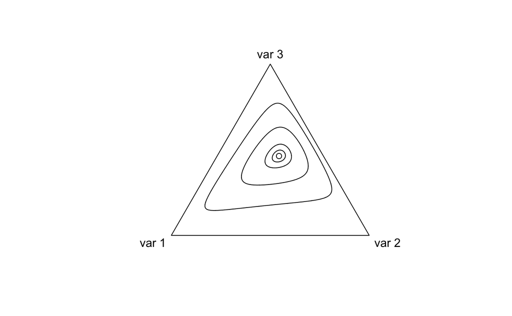

```r
ellipses(mean(acomp(m1)),variation(acomp(m1)),10)
```

### Function 17. Balance between two groups.

Given a comp. variable $\mathbf{x}$, for each observation, the balance between two groups is given by:

$K \sum_{a\in A} N_b \ln x_a -K \sum_{b\in B} N_B \ln x_b\;\;\;$, where $\;\;\;K=\left(N_aN_b(N_a+N_b)\right)^{-1/2}$.

```r
balance = function(x,A,B){ # x matrix NxD (output Nx1), A, B vector of positions of each group
  if (length(A)==1){gA = matrix(x[,A])}
  if (length(A)>1){gA = (x[,A])}
  if (length(B)==1){gB = matrix(x[,B])}
  if (length(B)>1){gB = (x[,B])}

  Na = dim(gA)[2]
  Nb = dim(gB)[2]
  K = (Na*Nb*(Na+Nb))**(-0.5)
  res = numeric()
  for (t in (1:dim(x)[1])){
    res[t] = K*sum(Nb*log(gA[t,])) - K*sum(Na*log(gB[t,]))
  }
  return(matrix(res))
}
```

We can observe that it works: although the second part of $m_1$ is not more important than the “mean” of the two others, for the forth observation it is.

```r
m1
```

```
         [,1] [,2] [,3]
[1,] 0.250000 0.30 0.45
[2,] 0.249999 0.30 0.45
[3,] 0.200000 0.30 0.50
[4,] 0.200000 0.35 0.45
```

```r
#balance
balance(m1,c(2),c(1,3))
```

```
            [,1]
[1,] -0.09109797
[2,] -0.09109634
[3,] -0.04301325
[4,]  0.12586350
```